# R Notebook

| book_id | title | authors | average_rating | isbn | isbn13 | language_code | num_pages | ratings_count | text_reviews_count |
| --- | --- | --- | --- | --- | --- | --- | --- | --- | --- |
| 1 | Harry Potter and the Half-Blood Prince (Harry Potter #6) | J.K. Rowling-Mary GrandPré | 4.56 | 0439785960 | 9780439785969 | eng | 652 | 1944099 | 26249 |
| 2 | Harry Potter and the Order of the Phoenix (Harry Potter #5) | J.K. Rowling-Mary GrandPré | 4.49 | 0439358078 | 9780439358071 | eng | 870 | 1996446 | 27613 |
| 3 | Harry Potter and the Sorcerer's Stone (Harry Potter #1) | J.K. Rowling-Mary GrandPré | 4.47 | 0439554934 | 9780439554930 | eng | 320 | 5629932 | 70390 |
| 4 | Harry Potter and the Chamber of Secrets (Harry Potter #2) | J.K. Rowling | 4.41 | 0439554896 | 9780439554893 | eng | 352 | 6267 | 272 |
| 5 | Harry Potter and the Prisoner of Azkaban (Harry Potter #3) | J.K. Rowling-Mary GrandPré | 4.55 | 043965548X | 9780439655484 | eng | 435 | 2149872 | 33964 |
| 8 | Harry Potter Boxed Set Books 1-5 (Harry Potter #1-5) | J.K. Rowling-Mary GrandPré | 4.78 | 0439682584 | 9780439682589 | eng | 2690 | 38872 | 154 |
| 9 | Unauthorized Harry Potter Book Seven News: "Half-Blood Prince" Analysis and Speculation | W. Frederick Zimmerman | 3.69 | 0976540606 | 9780976540601 | en-US | 152 | 18 | 1 |
| 10 | Harry Potter Collection (Harry Potter #1-6) | J.K. Rowling | 4.73 | 0439827604 | 9780439827607 | eng | 3342 | 27410 | 820 |
| 12 | The Ultimate Hitchhiker's Guide: Five Complete Novels and One Story (Hitchhiker's Guide to the Galaxy #1-5) | Douglas Adams | 4.38 | 0517226952 | 9780517226957 | eng | 815 | 3602 | 258 |
| 13 | The Ultimate Hitchhiker's Guide to the Galaxy | Douglas Adams | 4.38 | 0345453743 | 9780345453747 | eng | 815 | 240189 | 3954 |

[output cut: 990 more lines]

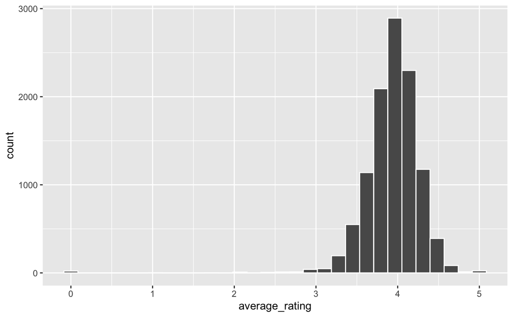

```r
books_tidy %>%
  ggplot(aes(x = average_rating))+
  geom_histogram(col = "white")
```

##Is the 2020 average different from the 2016 average?

```r
mean(books_tidy$average_rating, na.rm = TRUE)
```

```
[1] 3.937568
```

set up **Null**(H0) hypothesis - the hypothesis of no difference (skeptical position)

and **Alternative** (H1) hypothesis - hypothesis of difference

*two hypotheses must be mutually exclusive & exhaustive (cover all outcomes)*

$$H_0 : \mu_{average \ rating} = 3.93$$
$$H_1 : \mu_{average \ rating} \neq 3.93$$

```r
observed_stat <- mean(books_tidy$average_rating, na.rm = TRUE)
```

Is this significantly different from 2016s 3.93

Hypothesis Test Steps: > step 1 - decide on significance/alpha level (before looking at data) - usually 0.05 - set error rate which dictates how often we wrongly declare significance i.e. 5%

> step 2 - calculate the statistic from the sample

> step 3 - create the sampling distribution - bootstrapping - assume that it is TRUE during this

> step 4 - compare our calculated statistic with the sampling distribution - if calculated stat is far enough into the tail of distrubution, we call it significant - p-value^

> step 5 - if the p value < alpha we reject null hypothesis - if the p value > alpha we do not reject null hypothesis

##Hypothesis testing with `infer`

```r
observed_stat
```

```
[1] 3.937568
```

[output not shown]

The p-value means: how likely are you to see a result as extreme as yours, if null hypothesis is true

#Our observed stat of 3.937568 is significantly different from our null stat of 3.93, at an alpha level of 0. 05 (0.05 > 0.014), therefore evidence in support of our alternative hypothesis